# Activity: Graphical Exploration

Jason Abu

Due Date: 02/09/2020

## Front Matter

Install supporting R packages with necessary functions and data sets. You will need to add `library(DataComputing)` to the code chunk. Note the line `rm(list = ls())` at the beginning of the code chunk, this will effectively reset your R environment which can help avoid bugs when an analysis gets more complicated.

```r
rm(list = ls())      # cleans up your R environment
# load packages
library(mosaic)
library(DataComputing)
library(tidyverse)   # loads a group of useful packages including `ggplot2`
```

### Explore the `diamonds` data

*Task: Use R to produce one informative graphic of the `diamonds` data. The graphic should represent AT LEAST 3 variables. Write a few sentences to describe what we can learn from the graphic your have provided. (Note: do NOT write your narrative inside the code chunk.)*

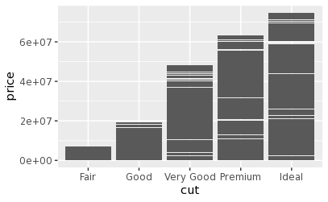

```r
# read `diamonds` data into R; it has been provided by the `ggplot2` package
data("diamonds", package = "ggplot2")
# The "diamonds" data describes the color of the diamonds in the dataset such as E, H, and F. It also describes the price of diamonds.
# add your code below for your one key data visualization
ggplot(data=diamonds,aes(x=cut,y=price ))+geom_bar(stat='identity',position='stack', width=.9)+scale_fill_brewer(type='seq',palette=1)
```

### Explore the cereal data

*Task: Use R to produce one informative graphic of the `cereal.csv` data. The graphic should represent AT LEAST 3 variables. Write a few sentences to describe what we can learn from the graphic your have provided. (Note: do NOT write your narrative inside the code chunk.)*

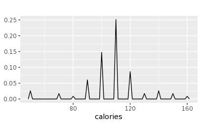

```r
# read CSV data set into R
CerealData <- read_csv(file = "cereal.csv")
# add your code below for your one key data visualization
ggplot( data = CerealData, aes(x = calories)) + geom_ash(binwidth = 1.5) + aes(colour = calories) + labs(title = "") + theme(legend.position = "right")
```

### Extension: programming style

The helper functions are great, but they produce ugly code. Clean up the `ggplot2` code that reproduces the required plots so that it aligns with the R Programming Style Guide Appendix in the *DataComputing* eBook https://dtkaplan.github.io/DataComputingEbook/.

```r
rm(list = ls())
```